# Modeling

## Simple Linear Regression

### Predicting Winning Percentage

For this section we will be using the `Teams` table.

```r
team_pred <- Teams %>%
  filter(yearID >= 2012, yearID < 2020)
```

Say we want to predict winning percentage **using a team’s run differential**. To do this we need to create two new variables: run differential (RD) and winning percentage (WPCT). Run differential is calculated with runs scored (R) and **runs allowed** (RA). **Calculating** winning percentage **requires** the amount of wins and losses.

```r
team_pred <- team_pred %>%
  mutate(RD = R - RA,
         WPCT = W / (W + L))
```

Now it’s time to build the model. The `lm()` function is used to fit linear models. It requires a formula, following the format: response ~ predictor(s). A response variable is the variable we are trying to predict. Predictor variables are used to make predictions. In this example, we will predict a team’s winning percentage (response) using its run differential (predictor).

```r
model1 <- lm(WPCT ~ RD, data = team_pred)
model1
```

```
##
## Call:
## lm(formula = WPCT ~ RD, data = team_pred)
##
## Coefficients:
## (Intercept)           RD
##   0.4999830    0.0006089
```

The general equation of a simple linear regression line is: $\hat{y} = b_0 + b_1 x$. **The symbols have the following meaning**:

- $\hat{y}$ = predicted value of the response variable
- $b_0$ = estimated y-intercept for the line
- $b_1$ = estimated slope for the line
- x = predictor value to plug in

This output provides us with an equation we can use to predict a team’s winning percentage based on their run differential:

$$\text{Predicted Win Pct} = 0.500 +
0.00061 * \text{Run Diff}$$

The **estimated y-intercept** for this model is 0.500. This means that we would predict a winning percentage of 0.500 for a team with a run differential of 0. In other words, teams who give up and score the same number of runs are predicted to be average. This makes a lot of sense for this example, but we will see later that y-intercept interpretations aren’t always applicable like this.

The **estimate slope** for our line is 0.00061. This tells us that our predicted winning percentage increases by 0.00061 for each additional run a team scores (or each fewer run they allow). Over a 162 game season, a change in winning percentage of 0.00061 is equivalent to around $162 * 0.00061 = 0.1$ wins. In other words, an increase of around 10 runs scored (or prevented) is associated with around 1 more win in a season.

The `summary()` function can give us some additional information about our linear regression model.

```r
summary(model1)
```

```
##
## Call:
## lm(formula = WPCT ~ RD, data = team_pred)
##
## Residuals:
##       Min        1Q    Median        3Q       Max
## -0.060481 -0.016448  0.000136  0.014840  0.081565
##
## Coefficients:
##              Estimate Std. Error t value Pr(>|t|)
## (Intercept) 5.000e-01  1.630e-03  306.74   <2e-16 ***
## RD          6.089e-04  1.414e-05   43.05   <2e-16 ***
## ---
## Signif. codes:  0 '***' 0.001 '**' 0.01 '*' 0.05 '.' 0.1 ' ' 1
##
## Residual standard error: 0.02525 on 238 degrees of freedom
## Multiple R-squared:  0.8862, Adjusted R-squared:  0.8857
## F-statistic:  1854 on 1 and 238 DF,  p-value: < 2.2e-16
```

**R-squared** values are used to describe how well the model fits the data. In this model, the R-squared value is 0.8862. This is saying that around 88.6% of variability in team winning percentage is explained by run differential.

This should not be the exclusive method to assess model fit, but it helps give us a good idea.

To visualize this data we can make a scatter plot and fit a line using `geom_smooth()`. If no method is specified, R will automatically fit the model it thinks is best. Since we fit a linear model above, the method should be “lm”.

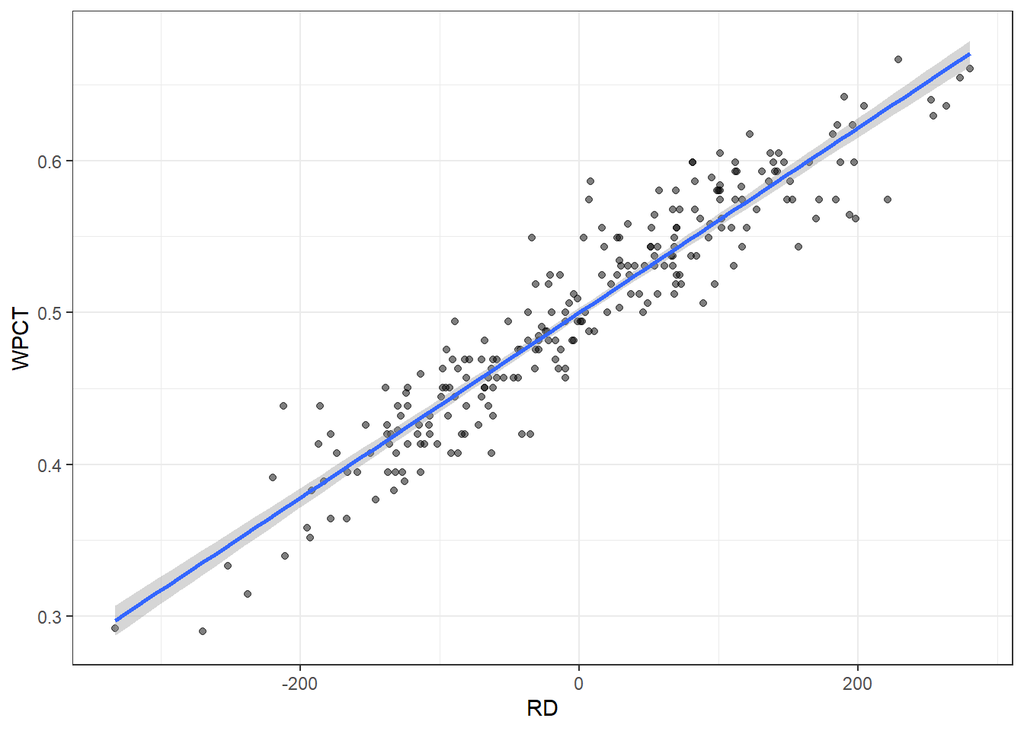

```r
team_pred %>%
  ggplot(aes(x = RD, y = WPCT)) +
  geom_point(alpha = 0.5) +
  geom_smooth(method = "lm") +
  theme_bw()
```

## Multiple Linear Regression

### Linear Weights

We are going to predict runs using singles, doubles, triples, homeruns, walks, hit-by-pitches, strikeouts, non-strikeouts, stolen bases,caught stealing, and sacrifice flies.

First, we need to create a variable for singles (‘X1B’) and a variable for non-strikeouts (‘nonSO’).

```r
team_pred <- team_pred %>%
  mutate(X1B = H - X2B - X3B - HR,
         nonSO = AB - H - SO)
```

```r
model2 <- lm(R ~ X1B + X2B + X3B + HR + BB + HBP + SO + nonSO + SB + CS + SF, data = team_pred)
summary(model2)
```

```
##
## Call:
## lm(formula = R ~ X1B + X2B + X3B + HR + BB + HBP + SO + nonSO +
##     SB + CS + SF, data = team_pred)
##
## Residuals:
##    Min     1Q Median     3Q    Max
## -47.81 -14.37   0.89  13.04  69.67
##
## Coefficients:
##              Estimate Std. Error t value Pr(>|t|)
## (Intercept) -81.21901  148.24516  -0.548  0.58432
## X1B           0.39787    0.03233  12.307  < 2e-16 ***
## X2B           0.85061    0.06261  13.586  < 2e-16 ***
## X3B           1.03933    0.17326   5.999 7.74e-09 ***
## HR            1.46736    0.04932  29.753  < 2e-16 ***
## BB            0.27187    0.02782   9.772  < 2e-16 ***
## HBP           0.42777    0.10061   4.252 3.09e-05 ***
## SO           -0.07631    0.03220  -2.370  0.01864 *
## nonSO        -0.06349    0.03324  -1.910  0.05740 .
## SB            0.19421    0.06119   3.174  0.00171 **
## CS           -0.48760    0.21522  -2.266  0.02441 *
## SF            0.54241    0.20892   2.596  0.01004 *
## ---
## Signif. codes:  0 '***' 0.001 '**' 0.01 '*' 0.05 '.' 0.1 ' ' 1
##
## Residual standard error: 21.41 on 228 degrees of freedom
## Multiple R-squared:  0.9264, Adjusted R-squared:  0.9228
## F-statistic: 260.7 on 11 and 228 DF,  p-value: < 2.2e-16
```

Now let’s try fitting a model with no intercept. We can accomplish this by putting “- 1” at the of the model equation.

```r
model2 <- lm(R ~ X1B + X2B + X3B + HR + BB + HBP + SO + nonSO + SB + CS + SF - 1, data = team_pred)
summary(model2)
```

```
##
## Call:
## lm(formula = R ~ X1B + X2B + X3B + HR + BB + HBP + SO + nonSO +
##     SB + CS + SF - 1, data = team_pred)
##
## Residuals:
##    Min     1Q Median     3Q    Max
## -48.01 -13.86   0.80  13.12  68.72
##
## Coefficients:
##       Estimate Std. Error t value Pr(>|t|)
## X1B    0.39067    0.02949  13.249  < 2e-16 ***
## X2B    0.85129    0.06250  13.620  < 2e-16 ***
## X3B    1.03715    0.17295   5.997 7.78e-09 ***
## HR     1.46017    0.04747  30.763  < 2e-16 ***
## BB     0.26895    0.02726   9.865  < 2e-16 ***
## HBP    0.42674    0.10043   4.249 3.13e-05 ***
## SO    -0.09294    0.01073  -8.662 8.47e-16 ***
## nonSO -0.08079    0.01037  -7.792 2.28e-13 ***
## SB     0.19451    0.06109   3.184  0.00166 **
## CS    -0.51912    0.20707  -2.507  0.01287 *
## SF     0.53241    0.20780   2.562  0.01105 *
## ---
## Signif. codes:  0 '***' 0.001 '**' 0.01 '*' 0.05 '.' 0.1 ' ' 1
##
## Residual standard error: 21.38 on 229 degrees of freedom
## Multiple R-squared:  0.9992, Adjusted R-squared:  0.9991
## F-statistic: 2.453e+04 on 11 and 229 DF,  p-value: < 2.2e-16
```

Here is a table of the of each MLR variable and their slope:

```r
kable(model2$coefficients, col.names = "Coefficient") %>% kable_styling("striped", full_width = FALSE)
```

|  | Coefficient |
| --- | --- |
| X1B | 0.3906674 |
| X2B | 0.8512873 |
| X3B | 1.0371486 |
| HR | 1.4601679 |
| BB | 0.2689488 |
| HBP | 0.4267400 |
| SO | -0.0929440 |
| nonSO | -0.0807918 |
| SB | 0.1945057 |
| CS | -0.5191153 |
| SF | 0.5324062 |

The coefficient for stolen bases is 0.1945. This means that a team will score 0.1945 runs for every base they steal, given that all other variables remain constant. A coefficient of -0.5191 for caught stealing is saying that the number of runs will decrease by -0.5191 for every time the team is caught stealing.

To see how good this model is we will plot the predicted runs against the actual runs. The line represents a perfect model.

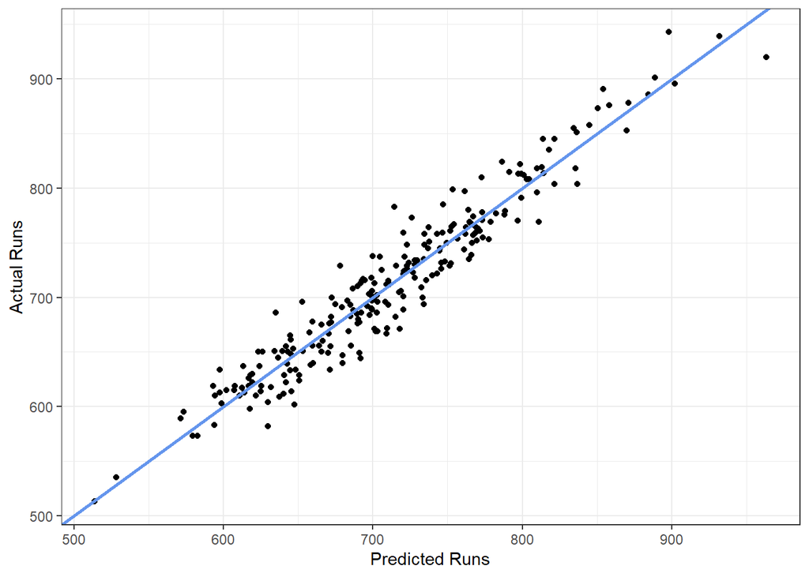

```r
team_pred %>%
  ggplot(aes(x = predict(model2), y = R)) +
  geom_point() +
  geom_abline(slope = 1, intercept = 0, color = "cornflowerblue", size = 1) +
  labs(x = "Predicted Runs", y = "Actual Runs") +
  theme_bw()
```

The points stay close to the line, which indicates that the model fits the data very well. This supports the same conclusion as the R-squared value.